# Tracing Hα Fibrils through Bayesian Deep Learning

### Haodi Jiang et al.

New Jersey Institute of Technology

## 1. Introduction

We present a new deep-learning method, named FibrilNet, for tracing chromospheric fibrils in Hα images of solar observations. Our method is implemented as a Bayesian convolutional neural network for probabilistic image segmentation with uncertainty quantification using a Monte Carlo (MC) dropout sampling technique. The FibrilNet tool can be applied to diverse data sets including high-resolution Hα images collected by BBSO/GST and Hα images from other solar observatories.

In this notebook, we provide an overview of the FibrilNet project, detailing how it can be applied to the Hα images from an active region (AR 12665) collected by BBSO/GST.

## 2. Workflow of FibrilNet

#### 2.1 Data Preparation and Loading

The data directory inside the data folder includes all training and test data sets required to run the notebook. The files are loaded and used during the testing and training process.

#### 2.2 Predicting with Pretrained Model

Note that the FibrilNet has large model file that can not be saved in public repository. Therefore, it must be downloaded first.

```python
from utils import *
download_model()
```

```
File: model\model.hdf5 already exists, no need to download it
```

There are default and pretrained models that can be used to predict without running your own trained model.

```
Working on: hab040_20170713_201558
Working on: hab060_20170713_201558
Working on: har000_20170713_201558
Working on: har040_20170713_201558
Working on: har060_20170713_201558
```

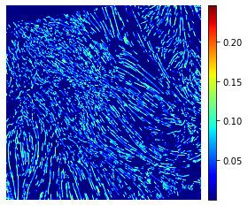

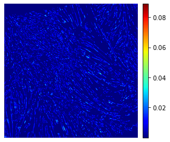

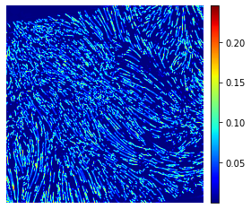

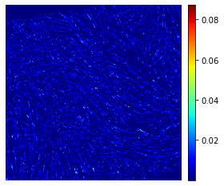

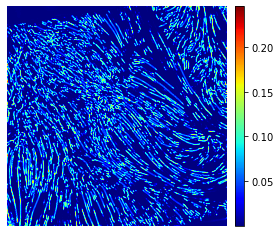

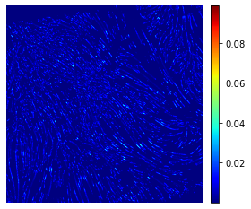

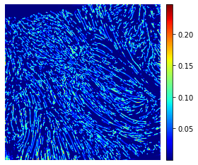

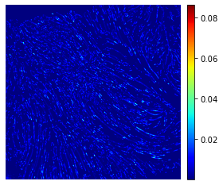

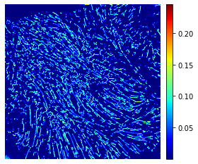

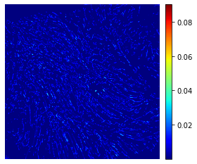

```python
from FibrilNet import *
from helper import predict
test_data_path = 'data/test/'
results_path = 'results/'
model = FibrilNet('model/model.hdf5')
predict(test_data_path, results_path, model)
```

#### 2.3 FibriNet Training and Testing

You may train a new model with your own data, and then predict.  
Since model training requires GPUs, it is omitted here.

```python
from helper import train
input_path ='data/'
model = train(input_path)
test_data_path = 'data/test/'
results_path = 'results/'
predict(test_data_path, results_path, model)
```

```
Found 242 images belonging to 1 classes.
Found 242 images belonging to 1 classes.
```

## 3. Conclusion

We develop a Bayesian deep-learning method, FibrilNet, for tracing chromospheric fibrils in Hα images of solar observations. The tool performs well on these high-resolution Hα images, predicting fibrils with uncertainty quantification and determining the orientations of the predicted fibrils. We further apply FibrilNet to full-disk Hα images from other solar observatories and additional high-resolution Hα images collected by BBSO/ GST, demonstrating the tool’s usability in diverse data sets

## Acknowledgment

The authors gratefully acknowledge the use of data from the Goode Solar Telescope (GST) of the Big Bear Solar Observatory (BBSO). The BBSO operation is supported by NJIT and U.S. NSF grant AGS-1821294. This work was supported by U.S. NSF grants AGS-1927578 and AGS-1954737.

## Reference

##### 1. Tracing Hα Fibrils through Bayesian Deep Learning. Haodi Jiang et al, 2021, ApJS 256 20

https://iopscience.iop.org/article/10.3847/1538-4365/ac14b7

##### 2. Inferring Line-of-sight Velocities and Doppler Widths from Stokes Profiles of GST/NIRIS Using Stacked Deep Neural Networks. Haodi Jiang et al, 2022, ApJ 939 66

https://iopscience.iop.org/article/10.3847/1538-4357/ac927e

##### 3. Identifying and Tracking Solar Magnetic Flux Elements with Deep Learning. Haodi Jiang et al, 2020, ApJS 250, 5

https://iopscience.iop.org/article/10.3847/1538-4365/aba4aa